# act_report

## WeRateDogs - Insights report

- In this report I will share some insights based of the tweet archive of Twitter user @dog_rates, also known as WeRateDogs. WeRateDogs is a Twitter account that rates people’s dogs with a humorous comment about the dog.

```python
import pandas as pd

import matplotlib.pyplot as plt
```

```python
df_merge=pd.read_csv('twitter_archive_master.csv')
```

### Visualization - What's the most liked category of dogs?

To find out what's the most liked categosy of dogs I used the rating system from weratedog . Basically the tweets are rated with a custom rating system having a rating numerator and a rating denominator . For my investigation I calculated the rating numerator/rating denominator and used it as a "likeiness" metric.

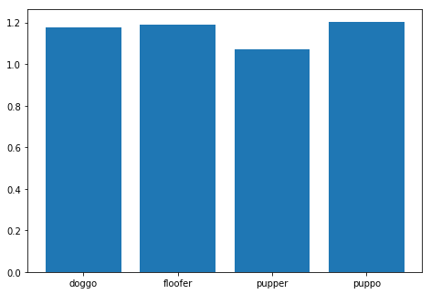

```python
doggo_mean = (df_merge.query('dog_stage == "doggo"')['rating_numerator']/df_merge.query('dog_stage == "doggo"')['rating_denominator']).mean()
puppo_mean = (df_merge.query('dog_stage == "puppo"')['rating_numerator']/df_merge.query('dog_stage == "puppo"')['rating_denominator']).mean()
pupper_mean = (df_merge.query('dog_stage == "pupper"')['rating_numerator']/df_merge.query('dog_stage == "pupper"')['rating_denominator']).mean()
floofer_mean =( df_merge.query('dog_stage == "floofer"')['rating_numerator']/df_merge.query('dog_stage == "floofer"')['rating_denominator']).mean()

fig = plt.figure()
ax = fig.add_axes([0,0,1,1])
dog_type = ['doggo', 'puppo' ,'pupper', 'floofer']
rating_avg = [doggo_mean,puppo_mean,pupper_mean,floofer_mean]
ax.bar(dog_type,rating_avg)
plt.show()
```

Conclusion: Puppo is the most liked category of dogs closely followed by floofer and doggo. The difference is small between the dog stages so we can conclude that stage has a small influence on the love a dog receives in social media .

### What is tweet most added to the favorites ?

The favourite count is a way to measure the success of a tweet so I looked for the tweets with the biggest favourite count to find out what was the tweet most added to te favourites.

```python
df_merge.sort_values(['favorite_count'], ascending =False ).head(10)
```

|  | tweet_id | timestamp | source_x | text | expanded_urls | rating_numerator | rating_denominator | name | contributors | coordinates | ... | p1 | p1_conf | p1_dog | p2 | p2_conf | p2_dog | p3 | p3_conf | p3_dog | dog_stage |
| --- | --- | --- | --- | --- | --- | --- | --- | --- | --- | --- | --- | --- | --- | --- | --- | --- | --- | --- | --- | --- | --- |
| 6726 | 744234799360020481 | 2016-06-18 18:26:18 | Twitter for iPhone | Here's a doggo realizing you can stand in a po... | https://twitter.com/dog_rates/status/744234799... | 13.0 | 10 | None | NaN | NaN | ... | Labrador_Retriever | 0.825333 | True | Ice_Bear | 0.044681 | False | Whippet | 0.018442 | True | None |
| 4740 | 744234799360020481 | 2016-06-18 18:26:18 | Twitter for iPhone | Here's a doggo realizing you can stand in a po... | https://twitter.com/dog_rates/status/744234799... | 13.0 | 10 | None | NaN | NaN | ... | Labrador_Retriever | 0.825333 | True | Ice_Bear | 0.044681 | False | Whippet | 0.018442 | True | None |
| 2754 | 744234799360020481 | 2016-06-18 18:26:18 | Twitter for iPhone | Here's a doggo realizing you can stand in a po... | https://twitter.com/dog_rates/status/744234799... | 13.0 | 10 | None | NaN | NaN | ... | Labrador_Retriever | 0.825333 | True | Ice_Bear | 0.044681 | False | Whippet | 0.018442 | True | None |
| 768 | 744234799360020481 | 2016-06-18 18:26:18 | Twitter for iPhone | Here's a doggo realizing you can stand in a po... | https://twitter.com/dog_rates/status/744234799... | 13.0 | 10 | None | NaN | NaN | ... | Labrador_Retriever | 0.825333 | True | Ice_Bear | 0.044681 | False | Whippet | 0.018442 | True | doggo |
| 4277 | 822872901745569793 | 2017-01-21 18:26:02 | Twitter for iPhone | Here's a super supportive puppo participating ... | https://twitter.com/dog_rates/status/822872901... | 13.0 | 10 | None | NaN | NaN | ... | Lakeland_Terrier | 0.196015 | True | Labrador_Retriever | 0.160329 | True | Irish_Terrier | 0.069126 | True | None |
| 305 | 822872901745569793 | 2017-01-21 18:26:02 | Twitter for iPhone | Here's a super supportive puppo participating ... | https://twitter.com/dog_rates/status/822872901... | 13.0 | 10 | None | NaN | NaN | ... | Lakeland_Terrier | 0.196015 | True | Labrador_Retriever | 0.160329 | True | Irish_Terrier | 0.069126 | True | None |
| 2291 | 822872901745569793 | 2017-01-21 18:26:02 | Twitter for iPhone | Here's a super supportive puppo participating ... | https://twitter.com/dog_rates/status/822872901... | 13.0 | 10 | None | NaN | NaN | ... | Lakeland_Terrier | 0.196015 | True | Labrador_Retriever | 0.160329 | True | Irish_Terrier | 0.069126 | True | None |
| 6263 | 822872901745569793 | 2017-01-21 18:26:02 | Twitter for iPhone | Here's a super supportive puppo participating ... | https://twitter.com/dog_rates/status/822872901... | 13.0 | 10 | None | NaN | NaN | ... | Lakeland_Terrier | 0.196015 | True | Labrador_Retriever | 0.160329 | True | Irish_Terrier | 0.069126 | True | puppo |
| 4368 | 807106840509214720 | 2016-12-09 06:17:20 | Twitter for iPhone | This is Stephan. He just wants to help. 13/10 ... | https://twitter.com/dog_rates/status/807106840... | 13.0 | 10 | Stephan | NaN | NaN | ... | Chihuahua | 0.505370 | True | Pomeranian | 0.120358 | True | Toy_Terrier | 0.077008 | True | None |
| 2382 | 807106840509214720 | 2016-12-09 06:17:20 | Twitter for iPhone | This is Stephan. He just wants to help. 13/10 ... | https://twitter.com/dog_rates/status/807106840... | 13.0 | 10 | Stephan | NaN | NaN | ... | Chihuahua | 0.505370 | True | Pomeranian | 0.120358 | True | Toy_Terrier | 0.077008 | True | None |

10 rows × 51 columns

Conclusion: The tweet https://twitter.com/dog_rates/status/744234799360020481 from 2016 was marked by the most people as their favourite

### Favourites vs retweets

There are different ways to express apreciation for a tweet, two of them are adding it to the favourites and share it with your followers (retweet). Are those two related ? A tweet that has a high favourite count will also have a high retweet count ? See conclusion bellow .

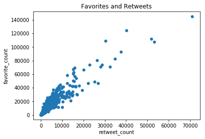

```python
df_merge.plot.scatter(x = 'retweet_count', y = 'favorite_count', title="Favorites and Retweets")
```

Conclusion : There is a correlation between favourite_count and retweet_count . A tweet that is marked as favourite is likely to be retweeted also